# Cocoa Percentage in Chocolate

### Visualization

We wanted to take a look at the connection of cocoa percentage and the manufacturers’ continent, so we’ve created box-plots graph to see how the cocoa percentages are scattered in each continent.

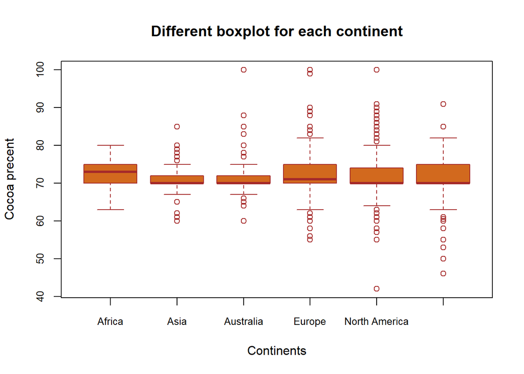

```r
boxplot(cocoa_data_clean$Cocoa_percent ~ cocoa_data_clean$Continent,
data=cocoa_data_clean,
main="Different boxplot for each continent",
xlab="Continents",
ylab="Cocoa precent",
col="chocolate",
border="brown",
cex.axis = 0.8
)
```

```r
rowSums(observed_table)
```

```
##        Africa          Asia     Australia        Europe North America
##            21           105            85           702          1363
## South America
##           167
```

We can see that the continents have a similar median values of cocoa percentage (around 70%), and the two middle quarters of each continent are between 70% and 75%. A noticeable difference between the boxes is within the extreme values. The continents with relatively more occurrences in the data set (Europe and North America) have a greater number of extremes.

### Modeling

Let’s examine the expected values for our independence test.

```r
chi_test <- chisq.test(observed_table)
chi_test$expected
```

```
##                  40%-66%   67%-74%   75%-80%  81%-100%
## Africa          2.810888  12.80802   4.22063  1.160458
## Asia           14.054441  64.04011  21.10315  5.802292
## Australia      11.377405  51.84200  17.08350  4.697094
## Europe         93.963979 428.15391 141.08964 38.792468
## North America 182.440033 831.30168 273.93901 75.319280
## South America  22.353254 101.85428  33.56406  9.228408
```

There are cells for Africa and Australia with expected data smaller then 5. Therefore, we’ve merged the data of the two continent into one.

```r
for (i in 1:4) {
  observed_table[1, i] <- observed_table[1, i] + observed_table[3, i]
}
fixed_observed_table = observed_table[-3,]
rownames(fixed_observed_table)[1] <- "Africa & Australia"
```

Now each cell has a value greater then 5 and we can properly conduct our second test.

```r
chi_test <- chisq.test(fixed_observed_table)
chi_test$expected
```

```
##                      40%-66%   67%-74%   75%-80%  81%-100%
## Africa & Australia  14.18829  64.65002  21.30413  5.857552
## Asia                14.05444  64.04011  21.10315  5.802292
## Europe              93.96398 428.15391 141.08964 38.792468
## North America      182.44003 831.30168 273.93901 75.319280
## South America       22.35325 101.85428  33.56406  9.228408
```

```r
chi_test
```

```
##
##  Pearson's Chi-squared test
##
## data:  fixed_observed_table
## X-squared = 62.293, df = 12, p-value = 8.594e-09
```

### Conclusion

Our PV is smaller then 5%. In that significance level, we deny the null hypothesis and accept the alternative. Therefore, we can state that the percentage of cocoa, and the continents of the chocolate manufacturers are indeed dependent.